# Análisis de Estudiantes

Carolina Cornacchia

14 septiembre 2025

## Objetivo

El objetivo del análisis es identificar la relación entre distintos hábitos y características de los estudiantes (ejemplo: horas de estudio, uso de dispositivos electrónicos, empleo a tiempo parcial, sueño, etc.) y el rendimiento académico medido en las notas obtenidas.

## Paso 1: Escojo un dataset

Primero escojo un dataset y lo cargo en R. El que elegí es de Kaggle y tiene que datos acerca de los hábitos de los estudiantes y sus notas de examen: `<https://www.kaggle.com/datasets/jayaantanaath/student-habits-vs-academic-performance>`

```r
students_data <- read.csv("C:/Users/Carol/OneDrive/Documentos/UTN/R/Regresion_lineal/student_habits_performance.csv", stringsAsFactors = FALSE)
```

Para poder ver el dataset puedo utilizar la función head:

```r
head(students_data)
```

```
##   student_id age gender study_hours_per_day social_media_hours netflix_hours
## 1      S1000  23 Female                 0.0                1.2           1.1
## 2      S1001  20 Female                 6.9                2.8           2.3
## 3      S1002  21   Male                 1.4                3.1           1.3
## 4      S1003  23 Female                 1.0                3.9           1.0
## 5      S1004  19 Female                 5.0                4.4           0.5
## 6      S1005  24   Male                 7.2                1.3           0.0
##   part_time_job attendance_percentage sleep_hours diet_quality
## 1            No                  85.0         8.0         Fair
## 2            No                  97.3         4.6         Good
## 3            No                  94.8         8.0         Poor
## 4            No                  71.0         9.2         Poor
## 5            No                  90.9         4.9         Fair
## 6            No                  82.9         7.4         Fair
##   exercise_frequency parental_education_level internet_quality
## 1                  6                   Master          Average
## 2                  6              High School          Average
## 3                  1              High School             Poor
## 4                  4                   Master             Good
## 5                  3                   Master             Good
## 6                  1                   Master          Average
##   mental_health_rating extracurricular_participation exam_score
## 1                    8                           Yes       56.2
## 2                    8                            No      100.0
## 3                    1                            No       34.3
## 4                    1                           Yes       26.8
## 5                    1                            No       66.4
## 6                    4                            No      100.0
```

## Paso 2: Analísis exploratorio: Aplico funciones para conocer el dataset

A su vez saco las medidas estadísticas y agrego la variable Part time job como numerica.

```r
students_data$part_time_job_num <- ifelse(students_data$part_time_job == "No", 1, 0)
head(students_data)
```

```
##   student_id age gender study_hours_per_day social_media_hours netflix_hours
## 1      S1000  23 Female                 0.0                1.2           1.1
## 2      S1001  20 Female                 6.9                2.8           2.3
## 3      S1002  21   Male                 1.4                3.1           1.3
## 4      S1003  23 Female                 1.0                3.9           1.0
## 5      S1004  19 Female                 5.0                4.4           0.5
## 6      S1005  24   Male                 7.2                1.3           0.0
##   part_time_job attendance_percentage sleep_hours diet_quality
## 1            No                  85.0         8.0         Fair
## 2            No                  97.3         4.6         Good
## 3            No                  94.8         8.0         Poor
## 4            No                  71.0         9.2         Poor
## 5            No                  90.9         4.9         Fair
## 6            No                  82.9         7.4         Fair
##   exercise_frequency parental_education_level internet_quality
```

[output cut: 20 more lines]

```r
summary(students_data)
```

```
##   student_id             age           gender          study_hours_per_day
##  Length:1000        Min.   :17.00   Length:1000        Min.   :0.00
##  Class :character   1st Qu.:18.75   Class :character   1st Qu.:2.60
##  Mode  :character   Median :20.00   Mode  :character   Median :3.50
##                     Mean   :20.50                      Mean   :3.55
##                     3rd Qu.:23.00                      3rd Qu.:4.50
##                     Max.   :24.00                      Max.   :8.30
##  social_media_hours netflix_hours   part_time_job      attendance_percentage
##  Min.   :0.000      Min.   :0.000   Length:1000        Min.   : 56.00
##  1st Qu.:1.700      1st Qu.:1.000   Class :character   1st Qu.: 78.00
##  Median :2.500      Median :1.800   Mode  :character   Median : 84.40
##  Mean   :2.506      Mean   :1.820                      Mean   : 84.13
##  3rd Qu.:3.300      3rd Qu.:2.525                      3rd Qu.: 91.03
##  Max.   :7.200      Max.   :5.400                      Max.   :100.00
##   sleep_hours    diet_quality       exercise_frequency parental_education_level
##  Min.   : 3.20   Length:1000        Min.   :0.000      Length:1000
##  1st Qu.: 5.60   Class :character   1st Qu.:1.000      Class :character
##  Median : 6.50   Mode  :character   Median :3.000      Mode  :character
##  Mean   : 6.47                      Mean   :3.042
##  3rd Qu.: 7.30                      3rd Qu.:5.000
##  Max.   :10.00                      Max.   :6.000
##  internet_quality   mental_health_rating extracurricular_participation
##  Length:1000        Min.   : 1.000       Length:1000
##  Class :character   1st Qu.: 3.000       Class :character
##  Mode  :character   Median : 5.000       Mode  :character
##                     Mean   : 5.438
##                     3rd Qu.: 8.000
##                     Max.   :10.000
##    exam_score     part_time_job_num
##  Min.   : 18.40   Min.   :0.000
##  1st Qu.: 58.48   1st Qu.:1.000
##  Median : 70.50   Median :1.000
##  Mean   : 69.60   Mean   :0.785
##  3rd Qu.: 81.33   3rd Qu.:1.000
##  Max.   :100.00   Max.   :1.000
```

```r
str(students_data)
```

```
## 'data.frame':    1000 obs. of  17 variables:
##  $ student_id                   : chr  "S1000" "S1001" "S1002" "S1003" ...
##  $ age                          : int  23 20 21 23 19 24 21 21 23 18 ...
##  $ gender                       : chr  "Female" "Female" "Male" "Female" ...
##  $ study_hours_per_day          : num  0 6.9 1.4 1 5 7.2 5.6 4.3 4.4 4.8 ...
##  $ social_media_hours           : num  1.2 2.8 3.1 3.9 4.4 1.3 1.5 1 2.2 3.1 ...
##  $ netflix_hours                : num  1.1 2.3 1.3 1 0.5 0 1.4 2 1.7 1.3 ...
##  $ part_time_job                : chr  "No" "No" "No" "No" ...
##  $ attendance_percentage        : num  85 97.3 94.8 71 90.9 82.9 85.8 77.7 100 95.4 ...
##  $ sleep_hours                  : num  8 4.6 8 9.2 4.9 7.4 6.5 4.6 7.1 7.5 ...
##  $ diet_quality                 : chr  "Fair" "Good" "Poor" "Poor" ...
##  $ exercise_frequency           : int  6 6 1 4 3 1 2 0 3 5 ...
##  $ parental_education_level     : chr  "Master" "High School" "High School" "Master" ...
##  $ internet_quality             : chr  "Average" "Average" "Poor" "Good" ...
##  $ mental_health_rating         : int  8 8 1 1 1 4 4 8 1 10 ...
##  $ extracurricular_participation: chr  "Yes" "No" "No" "Yes" ...
##  $ exam_score                   : num  56.2 100 34.3 26.8 66.4 100 89.8 72.6 78.9 100 ...
##  $ part_time_job_num            : num  1 1 1 1 1 1 0 0 1 1 ...
```

```r
sum(is.na(students_data))
```

```
## [1] 0
```

## Paso 3: Calculo la Matriz de Correlación

La **matriz de correlación** permite observar la relación lineal entre las diferentes variables consideradas en el análisis. A través de los coeficientes de correlación, se puede identificar qué variables presentan una asociación más fuerte (positiva o negativa) con las calificaciones obtenidas por los estudiantes. Este paso resulta fundamental para detectar patrones y posibles factores que influyen en el rendimiento académico. Además, ayuda a evitar la inclusión de variables redundantes en modelos posteriores, ya que una alta correlación entre variables puede indicar multicolinealidad.

En este caso, utilizaré las variables que tengan un índice de correlación mayor a 0.5:

```r
#Calculo la matriz de correlación en base a las siguientes variables
important_columns <- students_data[, c("age", "study_hours_per_day", "social_media_hours",
                                       "netflix_hours", "part_time_job_num", "attendance_percentage",
                                       "sleep_hours", "exercise_frequency", "mental_health_rating",
                                       "exam_score")]

correlation_with_exam_score <- cor(important_columns)[, "exam_score"]
correlation_with_exam_score
```

```
##                   age   study_hours_per_day    social_media_hours
##          -0.008906872           0.825418509          -0.166732885
##         netflix_hours     part_time_job_num attendance_percentage
##          -0.171779238           0.026608464           0.089835602
##           sleep_hours    exercise_frequency  mental_health_rating
##           0.121682911           0.160107464           0.321522931
##            exam_score
##           1.000000000
```

```r
# Seleccionar las variables con mayor correlación absoluta con 'medv'
selected_variables_students <- names(correlation_with_exam_score)[abs(correlation_with_exam_score) > 0.5]
selected_variables_students
```

```
## [1] "study_hours_per_day" "exam_score"
```

La variable a utilizar es: **Study_hours_per_day**

## Paso 4: Relizar el cálculo de Regresión Lineal

La regresión lineal se utilizó para evaluar en qué medida las variables explicativas influyen en la nota final de los estudiantes. Este modelo permite cuantificar el impacto de cada variable independiente sobre la variable dependiente (las calificaciones), generando una ecuación que puede ser interpretada tanto a nivel predictivo como explicativo. Los coeficientes del modelo muestran la dirección y magnitud de la influencia de cada factor, mientras que las métricas de ajuste (como el R²) permiten evaluar la capacidad del modelo para explicar la variabilidad en el desempeño académico.

```r
# Realizar la regresión lineal con las variables seleccionadas
lm_model_students <- lm(exam_score ~ study_hours_per_day, data =students_data )
summary(lm_model_students)
```

```
##
## Call:
## lm(formula = exam_score ~ study_hours_per_day, data = students_data)
##
## Residuals:
##     Min      1Q  Median      3Q     Max
## -25.979  -6.626   0.236   6.537  34.319
##
## Coefficients:
##                     Estimate Std. Error t value Pr(>|t|)
## (Intercept)          35.9102     0.7893   45.50   <2e-16 ***
## study_hours_per_day   9.4903     0.2055   46.19   <2e-16 ***
## ---
## Signif. codes:  0 '***' 0.001 '**' 0.01 '*' 0.05 '.' 0.1 ' ' 1
##
## Residual standard error: 9.539 on 998 degrees of freedom
## Multiple R-squared:  0.6813, Adjusted R-squared:  0.681
## F-statistic:  2134 on 1 and 998 DF,  p-value: < 2.2e-16
```

```r
# Obtener los coeficientes del modelo
coefficients <- coef(lm_model_students)
```

## Paso 5: Construir la nueva Ecuación Lineal

A partir de los datos disponibles, se calculó la ecuación de la regresión lineal que relaciona la variable dependiente (nota obtenida por el estudiante) con una o varias variables independientes.

```r
# Construir la ecuación del modelo en formato de texto
equation_text <- paste("La ecuación para obtener la nota de examen es -> Exam_score =", paste0(coefficients[1], " + ", paste0(coefficients[-1], " * ", names(coefficients[-1]), collapse = " + ")))

# Imprimir la ecuación de la regresión lineal
print(equation_text)
```

```
## [1] "La ecuación para obtener la nota de examen es -> Exam_score = 35.9101620340257 + 9.49025040589682 * study_hours_per_day"
```

```r
#Hago el cálculo según la ecuación obtenida
study_hours_per_day<- 4

# Calcular la predicción
exam_score_predicho <-35.9101620340257 + 9.49025040589682 * study_hours_per_day

# Imprimir la predicción
print(exam_score_predicho)
```

```
## [1] 73.87116
```

Esto significa que con 4 horas de estudio, la nota de examen será aproximadamente de 74%

## Paso 6: Gráfico de dispersión

El gráfico de dispersión permite visualizar la relación entre dos variables cuantitativas, mostrando cómo se distribuyen los datos y si existe algún patrón o tendencia entre ellas. En este análisis, se utilizó para observar como las horas de estudio se relacionan con las calificaciones obtenidas.

Cada punto representa a un estudiante, y la posición en los ejes refleja los valores de las dos variables analizadas. Este tipo de gráfico es especialmente útil para:

- Detectar correlaciones positivas o negativas entre variables.
- Identificar posibles valores atípicos o extremos.
- Obtener una primera impresión visual antes de construir modelos estadísticos como la regresión lineal.

En conjunto con la matriz de correlación y el modelo de regresión, el gráfico de dispersión permite comprender mejor las relaciones entre hábitos estudiantiles y rendimiento académico.

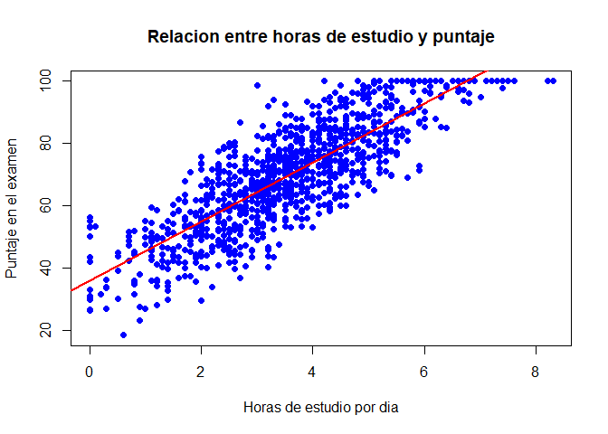

```r
# Gráfico de dispersión básico
plot(students_data$study_hours_per_day,
     students_data$exam_score,
     main = "Relacion entre horas de estudio y puntaje",
     xlab = "Horas de estudio por dia",
     ylab = "Puntaje en el examen",
     pch = 16,    # punto sólido
     col = "blue")

# Línea de regresión
abline(lm_model_students, col = "red", lwd = 2)
```

En este caso, el gráfico nos muestra que las variables tienen una relación positiva, ya que a más horas de estudio, mayor es la nota obtenida. La pendiente roja es muy marcada y los puntos azules la siguen, confirmando una relación clara y significativa.